# **Universidade Federal Rural de Pernambuco** **[Departamento de Matemática](http://www.dm.ufrpe.br/)** **Disciplina: Cálculo M I** **[Prof. Ricardo Machado](https://sites.google.com/site/ricardonunesmachadojr/)**

## Aula 3

## Derivabilidade e Continuidade. Regras de Derivação.

# Referências:

[figure not shown]

[figure not shown]

### Observação: Nota de aula produzida usando o software [SageMath](http://www.sagemath.org/), usando o notbook [Jupyter](https://jupyter.org/).

## 1 - Derivabilidade e Continuidade

## Já vimos que a função $f(x)=|x|$ não é derivável em $p=0$, entretanto esta função é contínua em $p=0$, o que nos mostra que uma função pode ser contínua em um ponto sem ser derivável neste ponto.

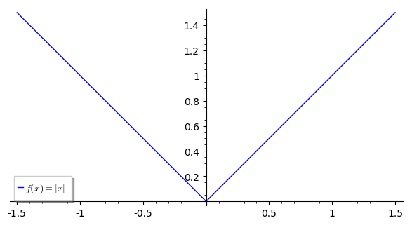

```python
plot(abs(x), (-1.5, 1.5), aspect_ratio=1, legend_label='$f(x)=|x|$')
```

## Observação: Desse modo, continuidade não implica diferenciabilidade. Entretanto, diferenciabilidade implica continuidade.

## Teorema. Se $f$ for derivável em $p$, então $f$ será contínua em $p$.

## Precisamos mostrar que $\displaystyle\lim_{x\rightarrow p} f(x) = f(p)$. Temos $f(x)-f(p) = \dfrac{f(x)-f(p)}{x-p}\cdot (x-p)$, para $x\neq p$. Logo $\displaystyle \lim_{x\rightarrow p} (f(x)-f(p)) = \lim_{x\rightarrow p}\dfrac{f(x)-f(p)}{x-p}\cdot \lim_{x\rightarrow p}(x-p) = f'(p)\cdot 0 = 0.$ E portanto, $\displaystyle\lim_{x\rightarrow p} f(x) = f(p)$

## Observação. Segue do Teorema que, se $f$ não for contínua em $p$, então $f$ não poderá ser derivável em $p$.

## Exercício 1. A função

## $$f(x) = \begin{cases} x^2, & x\leq 1 \\ 2, & x >1 \end{cases}$$ é derivável em $p=1$? Por quê?

> R. Calcular os limites laterais

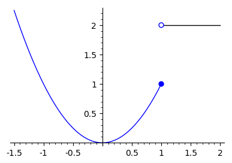

```python
p1 = plot(x^2, (-1.5, 1), figsize=[4,4])
c1 = circle((1,1), 0.04, fill=True)
p2 = plot(2, (1, 2), color='black')
c2 = circle((1,2), 0.04, fill=True, edgecolor='blue', facecolor='white')
(p1+p2+c1+c2)
```

## Exercício 2. Considere a função

## $$f(x) = \begin{cases} x^2, & x\leq 1 \\ 1, & x >1 \end{cases}$$ a) $f$ é contínua em $p=1$? b) $f$ é diferenciável em $p=1$?

> R. a) Calcular os limites laterais

> R. b) Calcular as derivadas por definição, usando limites laterais

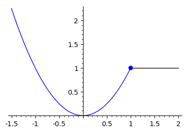

```python
p1 = plot(x^2, (-1.5, 1), figsize=[4,4])
p2 = plot(1, (1, 2), color='black')
c1 = circle((1,1), 0.04, fill=true)
(p1+p2+c1)
```

## Exercício 3. Considere a função

## $$f(x) = \begin{cases} x^2, & x\leq 1 \\ 2x-1, & x >1 \end{cases}$$ a) $f$ é diferenciável em $p=1$? b) $f$ é contínua em $p=1$?

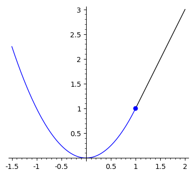

```python
p1 = plot(x^2, (-1.5, 1), figsize=[4,4])
p2 = plot(2*x-1, (1, 2), color='black')
c1 = circle((1,1), 0.04, fill=true)
(p1+p2+c1)
```

## d) $\displaystyle \left(\frac{f}{g}\right)'(p) = \lim_{x\rightarrow p} \frac{\frac{f(x)}{g(x)}-\frac{f(p)}{g(p)}}{x-p} =\lim_{x\rightarrow p} \frac{f(x)g(p) - f(p)g(x)}{x-p} \cdot \frac{1}{g(x)g(p)} = $ $ \hspace{2cm }=\displaystyle \lim_{x\rightarrow p} \frac{f(x)g(p) - f(p)g(x)}{x-p} \cdot \frac{1}{g(x)g(p)}$ $ \hspace{2cm }=\displaystyle \lim_{x\rightarrow p} \frac{f(x)g(p) -f(p)g(p) + f(p)g(p) - f(p)g(x)}{x-p} \cdot \frac{1}{g(x)g(p)}$ $ \hspace{2cm }=\displaystyle \lim_{x\rightarrow p} \left( \frac{f(x) -f(p)}{x-p}\cdot g(p) - f(p)\cdot\frac{g(x) -g(p)}{x-p}\right) \cdot \frac{1}{g(x)g(p)}$ $ \hspace{2cm }=\displaystyle \dfrac{f'(p)\cdot g(p) - f(p)\cdot g'(p)}{(g(p))^2}$.

## Exercício 1. Seja $f(x) = 4x^3+x^2$. Calcule.

## a) $f'(x)$ b) $f'(1)$

```python
f = 4*x^3+x^2
diff(f, x).show()
```

$$\newcommand{\Bold}[1]{\mathbf{#1}}12 \, x^{2} + 2 \, x$$

```python
diff(f, x)(x=1)
```

```
14
```

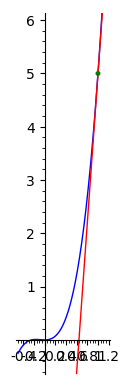

```python
grafico_f_tan(f, 1, (-0.5, 1.2), (-0.5 ,6))
```

## Exercício 2.

## Seja $g(x) = 5x^4+4$. Calcule $g'(x)$.

```python
g = 5*x^4+4
diff(g)
```

```
20*x^3
```

## Exercício 3.

## Seja $f(x) = \dfrac{2x+3}{x^2+1}$. Calcule $f'(x)$.

```python
f = (2*x+3)/(x^2+1)
diff(f, x).show()
```

$$\newcommand{\Bold}[1]{\mathbf{#1}}-\frac{2 \, {\left(2 \, x + 3\right)} x}{{\left(x^{2} + 1\right)}^{2}} + \frac{2}{x^{2} + 1}$$

```python
f = (2*x+3)/(x^2+1)
diff(f, x).full_simplify().show()
```

$$\newcommand{\Bold}[1]{\mathbf{#1}}-\frac{2 \, {\left(x^{2} + 3 \, x - 1\right)}}{x^{4} + 2 \, x^{2} + 1}$$

## Exercício 4.

## Seja $f(x) = (3x^2+1)e^x$. Calcule $f'(x)$.

```python
f = (3*x^2+1)*e^x
diff(f, x).full_simplify().show()
```

$$\newcommand{\Bold}[1]{\mathbf{#1}}{\left(3 \, x^{2} + 6 \, x + 1\right)} e^{x}$$

## Exercício 5.

## Seja $f(x) = \dfrac{sen(x)}{x+1}$. Calcule $f'(x)$.

```python
f = sin(x)/(x+1)
diff(f, x).full_simplify().show()
```

$$\newcommand{\Bold}[1]{\mathbf{#1}}\frac{{\left(x + 1\right)} \cos\left(x\right) - \sin\left(x\right)}{x^{2} + 2 \, x + 1}$$

## Exercício 6.

## Seja $f(x) = x^3+\ln{x}$. Calcule $f'(x)$.

```python
f = x^3+log(x)
diff(f, x).full_simplify().show()
```

$$\newcommand{\Bold}[1]{\mathbf{#1}}\frac{3 \, x^{3} + 1}{x}$$

## Exercício 7. Calcule a derivada.

## a) $f(x) = 3x^5 +\dfrac{1}{3}x^4 + x +2$ b) $g(x) = x^2 + \dfrac{1}{x^2} + \sqrt{x}$

```python
f = 3*x^5+(1/3)*x^4+x+2
diff(f, x).full_simplify().show()
```

$$\newcommand{\Bold}[1]{\mathbf{#1}}15 \, x^{4} + \frac{4}{3} \, x^{3} + 1$$

```python
f = x^2 + 1/(x^2) + sqrt(x)
diff(f, x).show()
```

$$\newcommand{\Bold}[1]{\mathbf{#1}}2 \, x + \frac{1}{2 \, \sqrt{x}} - \frac{2}{x^{3}}$$

## Exercício. 8

## Mostre as regras de derivação: c) $\tan'x = (\sec{x})^2 = \sec^2x$ d) $\sec'{x} = \sec{x}\cdot\tan{x}$ e) $cotg'x = -cosec^2x$ f) $cosec'x = -cosec~x\cdot cotg~x$